# Best Runner of NCAA College Football Players in Season 2012

Kaiyu Yan

Nov 28, 2018

```r
library(png)
library(knitr)
```

# Abstract

# Introduction

## Background

Trying to determine who was the best quarterback or running back through out the year is usually an interesting topic for media and college football fans. Also, to win a game, coach always need to put his best players on the field. Therefore, identifying and projecting the performance for players is particularly important for a team. People like to take one of the most basic statistic to measure performance. For example, yards per attempt(YPA), we like to use this measurement to determine the performance of a quarterback or running back’s performance. However, for most time, when we look at the leaders in yards per attempt, we will notice that the statistical data is not useful. Because the highest yards per attempt always dependent on the lowest number of attempts as shown in table 1.1. Therefore, for this project, we are trying to build a model that will generalize the most unbiased information to help us to determine the best performed player based on certain measurement.

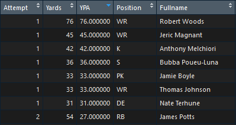

```r
img1_path <- "picture1.PNG"
img1 <- readPNG(img1_path, native = TRUE, info = TRUE)
# Small fig.width
include_graphics(img1_path)
```

# Data and Method

## Data Source

## Model Used

# EDA and Result

## EDA

## Model Choice

## Interpretation

## Model Checking

# Discussion

## Limitation

## Future Direction

```r
library(tidyverse)
Data_2012 <- read.csv("C:/Users/Mark/Desktop/cfbstats-com-2012-1-5-4/team-game-statistics.csv")

Team <- read.csv("C:/Users/Mark/Desktop/cfbstats-com-2012-1-5-4/team.csv")
team_defense <- read.csv("C:/Users/Mark/Desktop/cfbstats-com-2012-1-5-4/team-defense.csv")
team_efficient <- read.csv("C:/Users/Mark/Desktop/cfbstats-com-2012-1-5-4/team-efficient.csv")
power_index <- read.csv("C:/Users/Mark/Desktop/cfbstats-com-2012-1-5-4/power-index.csv")
schedule <- read.csv("C:/Users/Mark/Desktop/cfbstats-com-2012-1-5-4/game.csv")
Player_rush <- read.csv("C:/Users/Mark/Desktop/cfbstats-com-2012-1-5-4/rush.csv")
player <- read.csv("C:/Users/Mark/Desktop/cfbstats-com-2012-1-5-4/player.csv")
```

```r
rushing_stats <- aggregate(Data_2012[,3:4],list(Data_2012$Team.Code),sum)
colnames(rushing_stats)[1] <- "Team.Code"
rushing_stats <- inner_join(rushing_stats,Team,by = "Team.Code")
rushing_stats <- mutate(rushing_stats,YPC = Rush.Yard/Rush.Att)
colnames(Team)[2] <- "TEAM"
colnames(rushing_stats)[4] <- "TEAM"
A <- inner_join(power_index,Team,by = "TEAM")
A <- inner_join(A,team_efficient,by = "TEAM")
A <- inner_join(A,team_defense,by="TEAM")
A <- inner_join(A,rushing_stats,by="TEAM")
colnames(schedule)[3] <- "Team.Code"
schedule <- inner_join(schedule,Team,by = "Team.Code")
colnames(schedule)[4] <- "Team.Code1"
colnames(Team)[1] <- "Team.Code1"
schedule <- inner_join(schedule,Team,by = "Team.Code1")
schedule <- select(schedule,1,7,9)
colnames(schedule)[2] <- "Home Team"
colnames(schedule)[3] <- "Away Team"
dat <- as.data.frame(NULL)
for (i in 1:93){
  A1 <- filter(schedule,schedule$`Home Team` == A[i,2])
  A2 <- filter(schedule,schedule$`Away Team` == A[i,2])
  A2 <- A2[c(1,3,2)]
  colnames(A2)[2] <- "Home Team"
colnames(A2)[3] <- "Away Team"
  B <- rbind(A1,A2)
  dat <- rbind(dat,B)
}
colnames(dat)[3] <- "TEAM"
dat <- inner_join(dat,team_defense,by="TEAM")
dat <- inner_join(dat,power_index,by="TEAM")
dat <- inner_join(dat,team_efficient,by="TEAM")
dat <- select(dat,1:8,10,13,15)
Oppo_defense <- aggregate(dat[,5:11],list(dat$`Home Team`),mean)
colnames(Oppo_defense)[2] <- "Opp.Att.Allowed"
colnames(Oppo_defense)[3] <- "Opp.Yds.Allowed"
colnames(Oppo_defense)[4] <- "Opp.Ypc.Allowed"
colnames(Oppo_defense)[5] <- "Opp.Ypg.Allowed"
colnames(Oppo_defense)[1] <- "TEAM"
colnames(Oppo_defense)[6] <- "Opp.FPI"
colnames(Oppo_defense)[7] <- "Opp.Def.Eff"
colnames(Oppo_defense)[8] <- "Opp.Overall.Eff"


Team_stats <- select(A,2,3,7,8,10,17,18,20)
Team_stats <- inner_join(Team_stats,Oppo_defense,by = "TEAM")
Player_rush <- aggregate(Player_rush[,5:6],list(Player_rush$Player.Code),sum)
Player_rush <- mutate(Player_rush,YPA = Yards/Attempt)
player$Fullname <- as.character(paste(player$First.Name,player$Last.Name, sep = " "))
player <- select(player,1,2,7,14)
colnames(Player_rush)[1] <- "Player.Code"
Player_rush <- inner_join(Player_rush,player,by="Player.Code")
# Player_rush <- filter(Player_rush,Position == "RB")
Player_rush$Position <- as.character(Player_rush$Position)
 Player_rush$Position[Player_rush$Position == ""] <- NA
 Player_rush$Attempt[Player_rush$Attempt<1]  <- NA
 Player_rush <- na.omit(Player_rush)
Player_rush <- select(Player_rush,-1)
colnames(Player_rush)[4] <- "Team.Code1"
Player_rush <- inner_join(Player_rush,Team,by ="Team.Code1" )
Player_rush <- select(Player_rush,-4,-8)
Player_rush <- inner_join(Player_rush,Team_stats,by = "TEAM")
DT::datatable(Player_rush,
          filter = 'top', options = list(
            pageLength = 12, autoWidth = TRUE
          ))
```

|  | Attempt | Yards | YPA | Position | Fullname | TEAM | FPI | OFFENSE | DEFENSE | OVERALL | Rush.Att | Rush.Yard | YPC | Opp.Att.Allowed | Opp.Yds.Allowed | Opp.Ypc.Allowed | Opp.Ypg.Allowed | Opp.FPI | Opp.Def.Eff | Opp.Overall.Eff |
| --- | --- | --- | --- | --- | --- | --- | --- | --- | --- | --- | --- | --- | --- | --- | --- | --- | --- | --- | --- | --- |
| 1 | 17 | 18 | 1.05882352941176 | QB | James Lark | BYU | 11 | 46.1 | 81.8 | 68.1 | 505 | 1991 | 3.94257425742574 | 466.666666666667 | 1978.77777777778 | 4.17777777777778 | 160.9 | 6.58888888888889 | 62.1333333333333 | 61.1888888888889 |
| 2 | 86 | 196 | 2.27906976744186 | QB | Riley Nelson | BYU | 11 | 46.1 | 81.8 | 68.1 | 505 | 1991 | 3.94257425742574 | 466.666666666667 | 1978.77777777778 | 4.17777777777778 | 160.9 | 6.58888888888889 | 62.1333333333333 | 61.1888888888889 |
| 3 | 1 | 3 | 3 | K | Coleman Petersen | Utah | 6.8 | 36.1 | 61.3 | 51.5 | 446 | 1605 | 3.59865470852018 | 469.666666666667 | 2023.22222222222 | 4.27777777777778 | 167.522222222222 | 8.15555555555556 | 62.9222222222222 | 62.4888888888889 |
| 4 | 228 | 1137 | 4.98684210526316 | RB | D.J. Harper | Boise State | 8.9 | 59 | 73.5 | 72.6 | 478 | 2186 | 4.57322175732218 | 456.454545454545 | 1837.54545454545 | 3.94545454545455 | 149.7 | -2.76363636363636 | 47.8818181818182 | 42.3090909090909 |
| 5 | 40 | 6 | 0.15 | QB | Robert Marve | Purdue | 2.8 | 42.2 | 54.2 | 49 | 475 | 2135 | 4.49473684210526 | 444.6 | 1873.3 | 4.18 | 156.11 | 6.21 | 56.37 | 54.39 |
| 6 | 1 | 4 | 4 | RB | Larry Dawson | Kent State | 1.4 | 46.4 | 60.2 | 60.4 | 584 | 3161 | 5.41267123287671 | 470.222222222222 | 2257.77777777778 | 4.73333333333333 | 187.611111111111 | -4.83333333333333 | 41.5333333333333 | 40.0888888888889 |
| 7 | 15 | 57 | 3.8 | RB | James Morrison | Arizona State | 12.4 | 66.3 | 68.7 | 71.6 | 599 | 2669 | 4.45575959933222 | 465.6 | 2117.1 | 4.52 | 175.58 | 6.29 | 55.8 | 54.88 |
| 8 | 1 | 0 | 0 | WR | A.J. Pickens | Arizona State | 12.4 | 66.3 | 68.7 | 71.6 | 599 | 2669 | 4.45575959933222 | 465.6 | 2117.1 | 4.52 | 175.58 | 6.29 | 55.8 | 54.88 |
| 9 | 113 | 506 | 4.47787610619469 | QB | Matt Scott | Arizona | 7.5 | 75.4 | 47 | 62.9 | 544 | 2961 | 5.44301470588235 | 465.5 | 1961 | 4.19166666666667 | 161.9 | 9.43333333333333 | 60.8416666666667 | 61.8416666666667 |
| 10 | 104 | 438 | 4.21153846153846 | QB | Ryan Aplin | Arkansas State | 2.7 | 69.6 | 49.9 | 57.2 | 540 | 2700 | 5 | 482 | 2040.14285714286 | 4.2 | 168 | -0.942857142857143 | 50.4428571428571 | 47.4285714285714 |

[output cut: 1077 more lines]

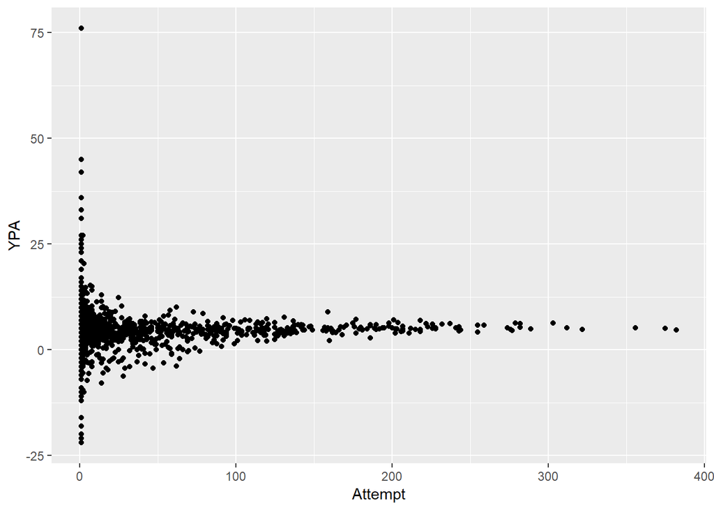

```r
ggplot(data = Player_rush)+
  geom_point(mapping = aes(x=Attempt,y = YPA))
```

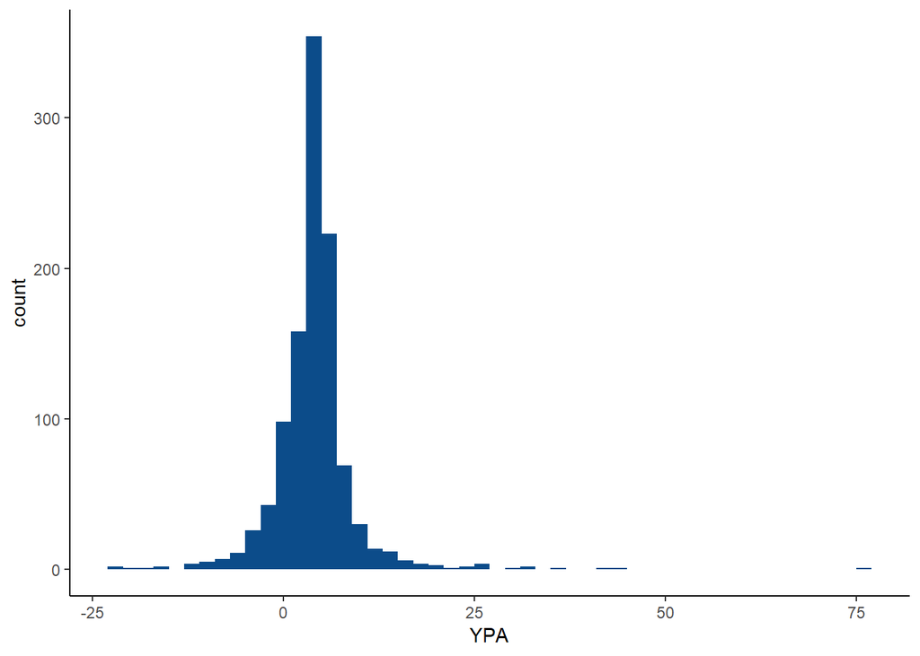

```r
ggplot(data = Player_rush) +
  aes(x = YPA) +
  geom_histogram(bins = 50, fill = "#0c4c8a") +
  theme_classic()
```

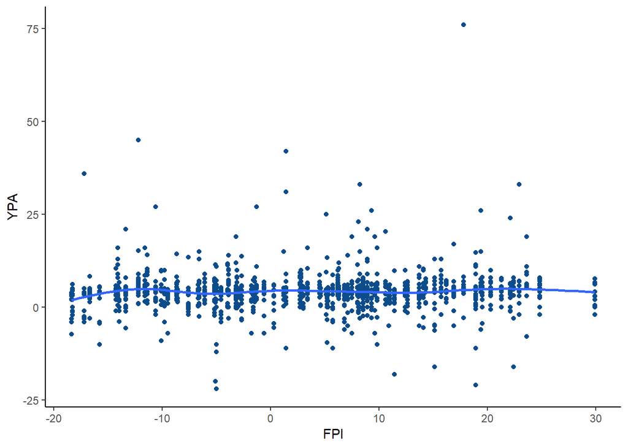

```r
ggplot(data = Player_rush) +
  aes(x = FPI, y = YPA) +
  geom_point(color = "#0c4c8a") +
  geom_smooth(se = F) +
  theme_classic()
```

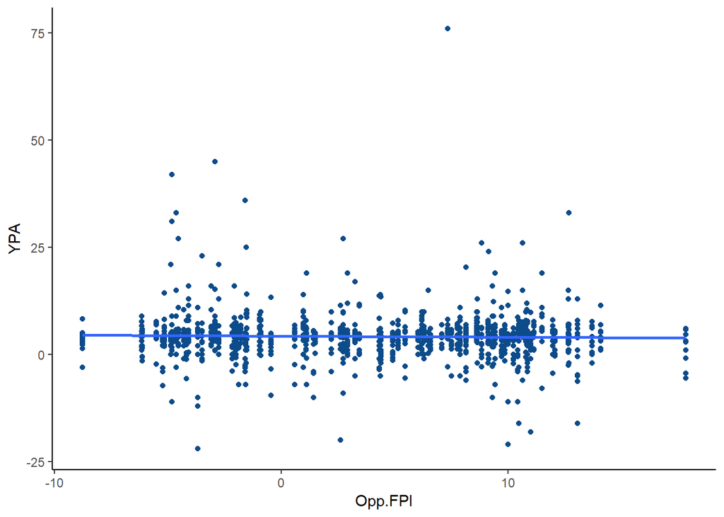

```r
ggplot(data = Player_rush) +
  aes(x = Opp.FPI, y = YPA) +
  geom_point(color = "#0c4c8a") +
  geom_smooth(se = F) +
  theme_classic()
```

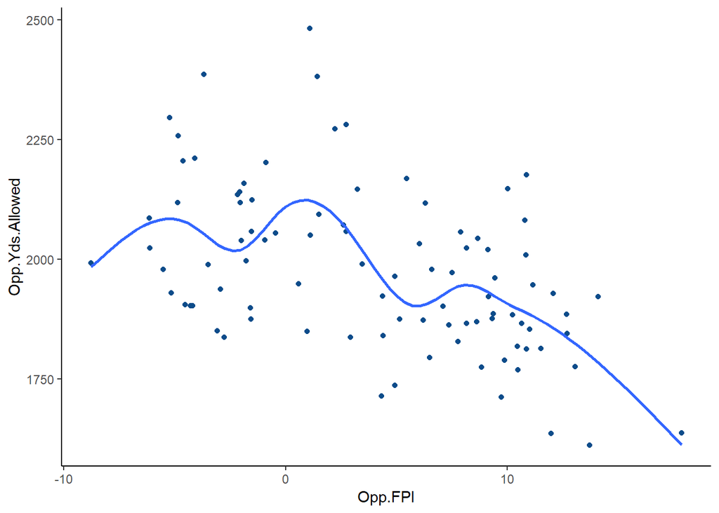

```r
ggplot(data = Player_rush) +
  aes(x = Opp.FPI, y = Opp.Yds.Allowed) +
  geom_point(color = "#0c4c8a") +
  geom_smooth(se = F) +
  theme_classic()
```

```r
library(nlme)
m1 <- lme(fixed = YPA~OFFENSE+Rush.Att+YPC+Opp.Ypc.Allowed+Opp.FPI,random = ~1|TEAM,data=Player_rush)
summary(m1)
```

```
## Linear mixed-effects model fit by REML
##  Data: Player_rush
##        AIC      BIC    logLik
##   6852.178 6892.063 -3418.089
##
## Random effects:
##  Formula: ~1 | TEAM
##          (Intercept) Residual
## StdDev: 0.0004811699 5.568419
##
## Fixed effects: YPA ~ OFFENSE + Rush.Att + YPC + Opp.Ypc.Allowed + Opp.FPI
##                      Value Std.Error  DF   t-value p-value
## (Intercept)      2.9057005  3.379082 994  0.859908  0.3900
## OFFENSE         -0.0097366  0.012393  87 -0.785638  0.4342
## Rush.Att        -0.0008108  0.002120  87 -0.382414  0.7031
## YPC              1.4819989  0.340818  87  4.348352  0.0000
## Opp.Ypc.Allowed -0.9640452  0.774982  87 -1.243959  0.2169
## Opp.FPI         -0.0534901  0.032019  87 -1.670575  0.0984
##  Correlation:
##                 (Intr) OFFENS Rsh.At YPC    Op.Y.A
## OFFENSE          0.026
## Rush.Att        -0.215  0.029
## YPC             -0.002 -0.544 -0.555
## Opp.Ypc.Allowed -0.952  0.035  0.134 -0.170
## Opp.FPI         -0.317 -0.415  0.129  0.099  0.281
##
## Standardized Within-Group Residuals:
##        Min         Q1        Med         Q3        Max
## -4.7400945 -0.3554139  0.0107298  0.2631192 12.7303688
##
## Number of Observations: 1087
## Number of Groups: 93
```

```r
library(lme4)
m2 <- lmer(YPA~ FPI+ (1|TEAM),Player_rush)
summary(m2)
```

```
## Linear mixed model fit by REML ['lmerMod']
## Formula: YPA ~ FPI + (1 | TEAM)
##    Data: Player_rush
##
## REML criterion at convergence: 6852.8
##
## Scaled residuals:
##     Min      1Q  Median      3Q     Max
## -4.5204 -0.3433  0.0000  0.2646 12.5869
##
## Random effects:
##  Groups   Name        Variance Std.Dev.
##  TEAM     (Intercept)  0.6515  0.8072
##  Residual             31.2633  5.5914
## Number of obs: 1087, groups:  TEAM, 93
##
## Fixed effects:
##             Estimate Std. Error t value
## (Intercept)  4.14272    0.19744  20.983
## FPI          0.02082    0.01617   1.288
##
## Correlation of Fixed Effects:
##     (Intr)
## FPI -0.277
```

```r
head(fixef(m2))
```

```
## (Intercept)         FPI
##  4.14271567  0.02081795
```

```r
head(ranef(m2)$TEAM)
```

```
##               (Intercept)
## Air Force      0.29889100
## Akron         -0.60987743
## Alabama       -0.18894827
## Arizona        0.02634157
## Arizona State -0.07386908
## Arkansas      -0.20664178
```

```r
head(coef(m2)$TEAM)
```

```
##               (Intercept)        FPI
## Air Force        4.441607 0.02081795
## Akron            3.532838 0.02081795
## Alabama          3.953767 0.02081795
## Arizona          4.169057 0.02081795
## Arizona State    4.068847 0.02081795
## Arkansas         3.936074 0.02081795
```